# Tugas Kelompok MPDW - P1

# 1 Deskripsi Data

# 2 Library yang digunakan

```r
library("forecast")
```

```r
library("graphics")
library("TTR")
library("rio")
library(quantmod)
library(zoo)
library(ggplot2)
```

# 3 Import Data

```r
library(readxl)
data1 <- read_excel("C:\\Users\\ASUS\\OneDrive\\Documents\\SEM 5\\MPDW\\Data_Cuaca_Bogor_Per_Jam.xlsx", sheet = "Anggota_1")

#via csv gunakan read.csv("namafile.csv")
#data1 <- read.csv("Data_1.csv")

# menampilkan 5 data pertama
head(data1)
```

| No | Tanggal | Waktu | Suhu Rata Rata (°C) |
| --- | --- | --- | --- |
| 1 | 2025-01-01 | 1899-12-31 00:00:00 | 23.9 |
| 2 | 2025-01-01 | 1899-12-31 01:00:00 | 23.6 |
| 3 | 2025-01-01 | 1899-12-31 02:00:00 | 23.3 |
| 4 | 2025-01-01 | 1899-12-31 03:00:00 | 23.1 |
| 5 | 2025-01-01 | 1899-12-31 04:00:00 | 22.7 |
| 6 | 2025-01-01 | 1899-12-31 05:00:00 | 22.3 |

# 4 Cek struktur data

```r
nrow(data1)
```

```
## [1] 240
```

```r
head(data1)
```

| No | Tanggal | Waktu | Suhu Rata Rata (°C) |
| --- | --- | --- | --- |
| 1 | 2025-01-01 | 1899-12-31 00:00:00 | 23.9 |
| 2 | 2025-01-01 | 1899-12-31 01:00:00 | 23.6 |
| 3 | 2025-01-01 | 1899-12-31 02:00:00 | 23.3 |
| 4 | 2025-01-01 | 1899-12-31 03:00:00 | 23.1 |
| 5 | 2025-01-01 | 1899-12-31 04:00:00 | 22.7 |
| 6 | 2025-01-01 | 1899-12-31 05:00:00 | 22.3 |

```r
sum(is.na(data1))
```

```
## [1] 0
```

# 5 Data time series dan eksplorasi data

```r
data1.ts <- ts(data1$`Suhu Rata Rata (°C)`)
summary(data1.ts)
```

```
##    Min. 1st Qu.  Median    Mean 3rd Qu.    Max.
##   21.10   23.60   24.95   25.68   27.70   31.20
```

## 5.1 Plot Time Series

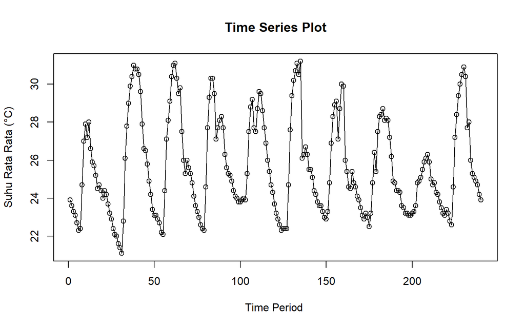

```r
# Buat plot untuk harga emas
plot(data1.ts, xlab="Time Period ", ylab="Suhu Rata Rata (°C)",
        main = "Time Series Plot")
points(data1.ts)
```

```r
library(ggplot2)

data1$DateTime <- as.POSIXct(
  paste(as.Date(data1$Tanggal), data1$Waktu),
  format = "%Y-%m-%d %H:%M:%S",
  tz = "Asia/Jakarta"
)

# cek data dan missing value
head(data1$DateTime)
```

```
## [1] NA NA NA NA NA NA
```

```r
sum(is.na(data1$DateTime))   # pastikan 0
```

```
## [1] 240
```

```r
data1$DateTime <- seq(
  from = as.POSIXct("2025-01-01 00:00:00", tz = "Asia/Jakarta"),
  by = "hour",
  length.out = nrow(data1)
)
sum(is.na(data1$DateTime))
```

```
## [1] 0
```

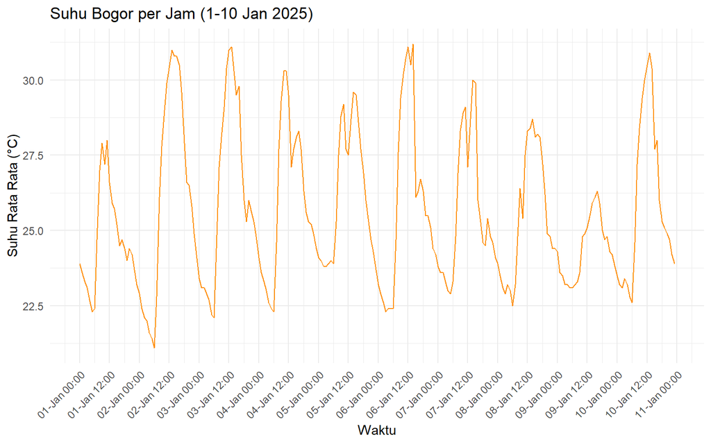

```r
ggplot(data1, aes(x = DateTime, y = `Suhu Rata Rata (°C)`)) +
  geom_line(color = "darkorange") +
  labs(title = "Suhu Bogor per Jam (1-10 Jan 2025)", x = "Waktu", y = "Suhu Rata Rata (°C)") +
  scale_x_datetime(date_breaks = "12 hour", date_labels = "%d-%b %H:%M") + #tampilin jam:menit
  theme_minimal() +
  theme(axis.text.x = element_text(angle = 45, hjust = 1))
```

# 6 Pembagian data

Data dibagi menjadi 80% data latih dan 20% data uji

```r
# hitung jumlah data
n <- length(data1.ts)
#tentuin batas 80%
n_train <- floor(0.8 * n); n_train
```

```
## [1] 192
```

```r
# bagi data
training_ma <- data1[1:n_train, ]
testing_ma  <- data1[(n_train+1):n, ]

# ubah ke time series
train_ma.ts <- ts(training_ma$`Suhu Rata Rata (°C)`)
train_ma.ts <- na.locf(train_ma.ts)
sum(is.na(train_ma.ts))   # pastikan 0
```

```
## [1] 0
```

```r
test_ma.ts  <- ts(testing_ma$`Suhu Rata Rata (°C)`)
test_ma.ts <- na.locf(test_ma.ts)
sum(is.na(test_ma.ts))   # pastikan 0
```

```
## [1] 0
```

```r
n - n_train
```

```
## [1] 48
```

# 7 Metode Pemulusan

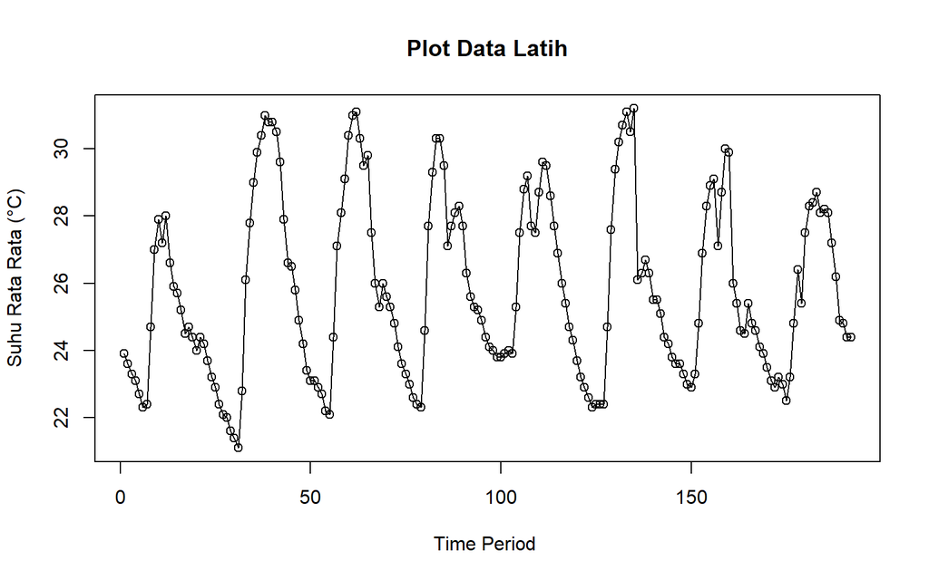

```r
# bikin plot data latih dan uji
plot_train.n1 <- plot(train_ma.ts, xlab="Time Period ", ylab="Suhu Rata Rata (°C)",
        main = "Plot Data Latih")
points(train_ma.ts)
```

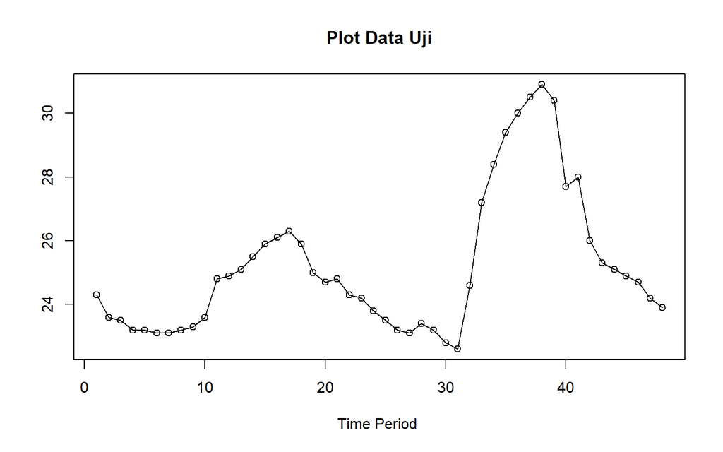

```r
plot_test.n1 <- plot(test_ma.ts, xlab="Time Period ", ylab="",
        main = "Plot Data Uji")
points(test_ma.ts)
```

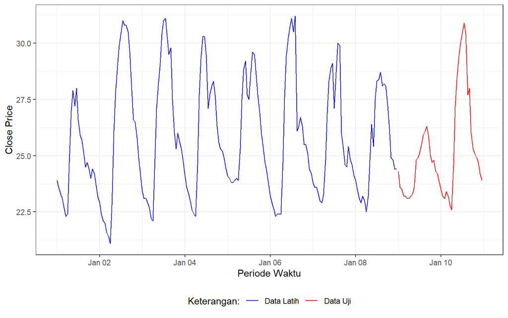

```r
# Data gab
library(ggplot2)
ggplot() +
  geom_line(data = training_ma, aes(x = DateTime, y = `Suhu Rata Rata (°C)`, col = "Data Latih")) +
  geom_line(data = testing_ma, aes(x = DateTime, y = `Suhu Rata Rata (°C)`, col = "Data Uji")) +
  labs(x = "Periode Waktu", y = "Close Price", color = "Legend") +
  scale_colour_manual(name = "Keterangan:",
                      breaks = c("Data Latih", "Data Uji"),
                      values = c("blue", "red")) +
  theme_bw() +
  theme(legend.position = "bottom",
        plot.caption = element_text(hjust = 0.5, size = 12))
```

## 7.1 Single Moving Average

Selanjutnya dilakukan peramalan sebanyak 48 periode sesuai dengan jumlah data uji. Pada metode SMA, seluruh hasil peramalan untuk 48 periode ke depan akan memiliki nilai yang sama dengan hasil ramalan satu periode ke depan. (48 periode karena m/parametenya 4 jadi kek data uji 192/4 = 48 periode)

```r
#SMA dengan parameter m=4 jam
data.sma.n1 <-SMA(train_ma.ts, n=4); data.sma.n1
```

```
## Time Series:
## Start = 1
## End = 192
## Frequency = 1
##   [1]     NA     NA     NA 23.475 23.175 22.850 22.625 23.025 24.100 25.500
##  [11] 26.700 27.525 27.425 26.925 26.550 25.850 25.325 25.025 24.700 24.400
##  [21] 24.375 24.250 24.075 23.875 23.500 23.050 22.650 22.350 22.025 21.775
##  [31] 21.525 21.725 22.850 24.450 26.425 28.200 29.275 30.075 30.525 30.750
##  [41] 30.775 30.425 29.700 28.650 27.650 26.700 25.950 25.350 24.575 23.900
##  [51] 23.450 23.125 22.950 22.725 22.475 22.850 23.950 25.425 27.175 28.675
##  [61] 29.650 30.400 30.700 30.475 30.175 29.275 28.200 27.150 26.200 25.725
##  [71] 25.550 25.425 24.950 24.450 23.950 23.500 23.125 22.825 22.575 22.975
##  [81] 24.250 25.975 27.975 29.400 29.850 29.300 28.650 28.100 27.800 27.950
##  [91] 27.600 26.975 26.225 25.600 25.250 24.950 24.650 24.350 24.075 23.925
## [101] 23.875 23.875 23.900 24.275 25.175 26.375 27.700 28.300 28.300 28.275
## [111] 28.375 28.825 29.100 28.850 28.175 27.300 26.500 25.750 25.100 24.525
## [121] 23.975 23.525 23.100 22.750 22.550 22.425 22.375 22.975 24.275 26.025
## [131] 27.975 29.475 30.350 30.625 30.875 29.725 28.525 27.575 26.350 26.200
## [141] 26.000 25.600 25.125 24.800 24.375 24.000 23.800 23.575 23.375 23.200
## [151] 23.125 23.500 24.475 25.825 27.225 28.300 28.350 28.450 28.725 28.925
## [161] 28.650 27.825 26.475 25.125 24.975 24.825 24.825 24.725 24.350 24.025
## [171] 23.650 23.350 23.175 23.050 22.900 22.975 23.375 24.225 24.950 26.025
## [181] 26.900 27.400 28.225 28.375 28.350 28.275 27.900 27.425 26.600 25.775
## [191] 25.075 24.625
```

Data pemulusan pada periode ke-t selanjutnya digunakan sebagai nilai peramalan pada periode ke t+1 sehingga hasil peramalan 1 periode kedepan adalah sebagai berikut.

```r
#ramalin data 1 periode ke depan
ramal_sma.n1 <- c(NA, data.sma.n1); ramal_sma.n1
```

```
##   [1]     NA     NA     NA     NA 23.475 23.175 22.850 22.625 23.025 24.100
##  [11] 25.500 26.700 27.525 27.425 26.925 26.550 25.850 25.325 25.025 24.700
##  [21] 24.400 24.375 24.250 24.075 23.875 23.500 23.050 22.650 22.350 22.025
##  [31] 21.775 21.525 21.725 22.850 24.450 26.425 28.200 29.275 30.075 30.525
##  [41] 30.750 30.775 30.425 29.700 28.650 27.650 26.700 25.950 25.350 24.575
##  [51] 23.900 23.450 23.125 22.950 22.725 22.475 22.850 23.950 25.425 27.175
##  [61] 28.675 29.650 30.400 30.700 30.475 30.175 29.275 28.200 27.150 26.200
##  [71] 25.725 25.550 25.425 24.950 24.450 23.950 23.500 23.125 22.825 22.575
##  [81] 22.975 24.250 25.975 27.975 29.400 29.850 29.300 28.650 28.100 27.800
##  [91] 27.950 27.600 26.975 26.225 25.600 25.250 24.950 24.650 24.350 24.075
## [101] 23.925 23.875 23.875 23.900 24.275 25.175 26.375 27.700 28.300 28.300
## [111] 28.275 28.375 28.825 29.100 28.850 28.175 27.300 26.500 25.750 25.100
## [121] 24.525 23.975 23.525 23.100 22.750 22.550 22.425 22.375 22.975 24.275
## [131] 26.025 27.975 29.475 30.350 30.625 30.875 29.725 28.525 27.575 26.350
## [141] 26.200 26.000 25.600 25.125 24.800 24.375 24.000 23.800 23.575 23.375
## [151] 23.200 23.125 23.500 24.475 25.825 27.225 28.300 28.350 28.450 28.725
## [161] 28.925 28.650 27.825 26.475 25.125 24.975 24.825 24.825 24.725 24.350
## [171] 24.025 23.650 23.350 23.175 23.050 22.900 22.975 23.375 24.225 24.950
## [181] 26.025 26.900 27.400 28.225 28.375 28.350 28.275 27.900 27.425 26.600
## [191] 25.775 25.075 24.625
```

```r
forecast_sma.n1 <- rep(ramal_sma.n1[length(ramal_sma.n1)], length(test_ma.ts)-1)

data.gab.sma <- cbind(
  aktual=c(data1.ts),
  pemulusan=c(data.sma.n1,rep(NA,length(test_ma.ts))),
  ramalan=c(ramal_sma.n1,rep(ramal_sma.n1[length(ramal_sma.n1)],length(test_ma.ts)-1)))

data.gab.sma #forecast 48 periode ke depan
```

```
##        aktual pemulusan ramalan
##   [1,]   23.9        NA      NA
##   [2,]   23.6        NA      NA
##   [3,]   23.3        NA      NA
##   [4,]   23.1    23.475      NA
##   [5,]   22.7    23.175  23.475
##   [6,]   22.3    22.850  23.175
##   [7,]   22.4    22.625  22.850
##   [8,]   24.7    23.025  22.625
##   [9,]   27.0    24.100  23.025
##  [10,]   27.9    25.500  24.100
##  [11,]   27.2    26.700  25.500
##  [12,]   28.0    27.525  26.700
##  [13,]   26.6    27.425  27.525
##  [14,]   25.9    26.925  27.425
```

[output cut: 226 more lines]

Adapun plot data deret waktu dari hasil peramalan yang dilakukan adalah sebagai berikut.

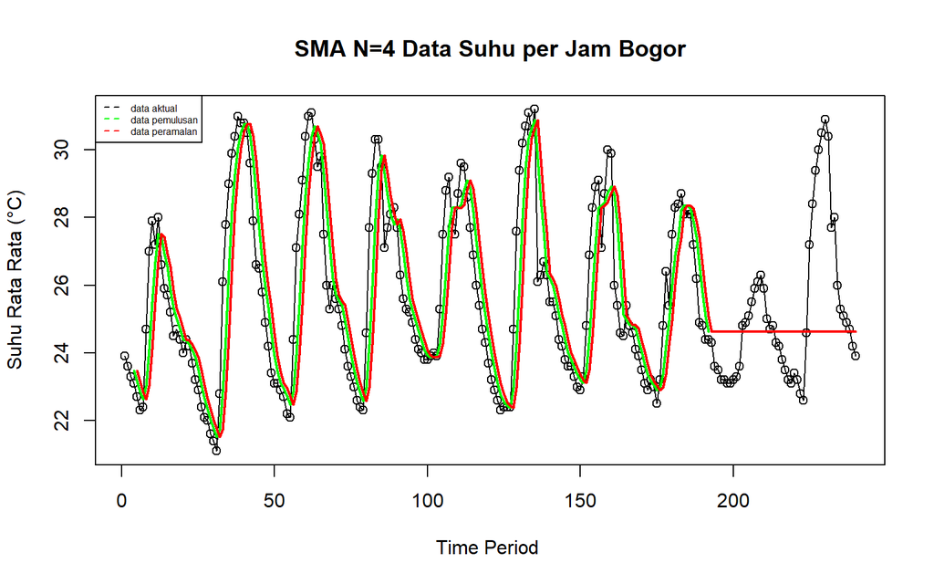

```r
ts.plot(data1.ts, xlab="Time Period ", ylab="Suhu Rata Rata (°C)", main= "SMA N=4 Data Suhu per Jam Bogor")
points(data1.ts)
lines(data.gab.sma[,2],col="green",lwd=2)
lines(data.gab.sma[,3],col="red",lwd=2)
legend("topleft",c("data aktual","data pemulusan","data peramalan"), lty=8, col=c("black","green","red"), cex=0.5)
```

### 7.1.1 Akurasi Data latih SMA

```r
error_train.sma =train_ma.ts-ramal_sma.n1[1:length(train_ma.ts)]

#index m+1 utk akurasi
SSE_train.sma = sum(error_train.sma[5:length(train_ma.ts)]^2)
MSE_train.sma = mean(error_train.sma[5:length(train_ma.ts)]^2)
MAPE_train.sma = mean(abs((error_train.sma[5:length(train_ma.ts)]/train_ma.ts[5:length(train_ma.ts)])*100))

akurasi_train.sma <- matrix(c(SSE_train.sma, MSE_train.sma, MAPE_train.sma))
row.names(akurasi_train.sma)<- c("SSE", "MSE", "MAPE")
colnames(akurasi_train.sma) <- c("Akurasi m = 4")
akurasi_train.sma
```

```
##      Akurasi m = 4
## SSE     711.763125
## MSE       3.785974
## MAPE      5.676477
```

### 7.1.2 Akurasi Data Uji SMA

```r
error_test.sma =test_ma.ts-data.gab.sma[193:240,3]

#index m+1 utk akurasi
SSE_test.sma = sum(error_test.sma^2)
MSE_test.sma = mean(error_test.sma^2)
MAPE_test.sma = mean(abs((error_test.sma/test_ma.ts*100)))

akurasi_test.sma <- matrix(c(SSE_test.sma, MSE_test.sma, MAPE_test.sma))
row.names(akurasi_test.sma)<- c("SSE", "MSE", "MAPE")
colnames(akurasi_test.sma) <- c("Akurasi m = 4")
akurasi_test.sma
```

```
##      Akurasi m = 4
## SSE     247.050000
## MSE       5.146875
## MAPE      6.059513
```

Perhitungan akurasi menggunakan data latih menghasilkan nilai MAPE yang kurang dari 10% sehingga nilai akurasi ini dapat dikategorikan sebagai sangat baik.

## 7.2 Double Moving Average

Proses pemulusan dengan rata rata dalam metode ini dilakukan sebanyak 2 kali.

```r
#DMA dengan parameter m=4 jam
dma.n1 <- SMA(data.sma.n1, n=4)
At <- 2*data.sma.n1 - dma.n1
Bt <- 2/(4-1)*(data.sma.n1-dma.n1)

data.dma.n1 <- At + Bt
ramal_dma.n1 <- c(NA, data.dma.n1)

t <- 1:48
f = c()

for (i in t) {
  f[i] = At[length(At)] + Bt[length(Bt)]*(i)
}

data.gab.dma <- cbind(aktual = c(data1.ts),
                   pemulusan1 = c(data.sma.n1,rep(NA,48)),
                   pemulusan2 = c(dma.n1, rep(NA,48)),
                   At = c(At, rep(NA,48)),
                   Bt = c(Bt,rep(NA,48)),
                   ramalan = c(ramal_dma.n1, f[-1]))
data.gab.dma
```

```
##        aktual pemulusan1 pemulusan2       At           Bt    ramalan
##   [1,]   23.9         NA         NA       NA           NA         NA
##   [2,]   23.6         NA         NA       NA           NA         NA
##   [3,]   23.3         NA         NA       NA           NA         NA
##   [4,]   23.1     23.475         NA       NA           NA         NA
##   [5,]   22.7     23.175         NA       NA           NA         NA
##   [6,]   22.3     22.850         NA       NA           NA         NA
##   [7,]   22.4     22.625   23.03125 22.21875 -0.270833333         NA
##   [8,]   24.7     23.025   22.91875 23.13125  0.070833333 21.9479167
##   [9,]   27.0     24.100   23.15000 25.05000  0.633333333 23.2020833
##  [10,]   27.9     25.500   23.81250 27.18750  1.125000000 25.6833333
##  [11,]   27.2     26.700   24.83125 28.56875  1.245833333 28.3125000
##  [12,]   28.0     27.525   25.95625 29.09375  1.045833333 29.8145833
##  [13,]   26.6     27.425   26.78750 28.06250  0.425000000 30.1395833
##  [14,]   25.9     26.925   27.14375 26.70625 -0.145833333 28.4875000
```

[output cut: 226 more lines]

Hasil pemulusan menggunakan metode DMA divisualisasikan sebagai berikut

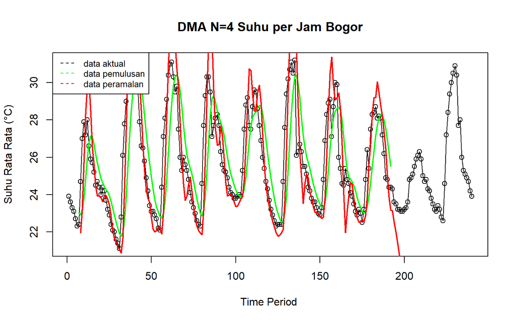

```r
ts.plot(data1.ts, xlab="Time Period ", ylab="Suhu Rata Rata (°C)", main= "DMA N=4 Suhu per Jam Bogor")
points(data1.ts)
lines(data.gab.dma[,3],col="green",lwd=2)
lines(data.gab.dma[,6],col="red",lwd=2)
legend("topleft",c("data aktual","data pemulusan","data peramalan"), lty=8, col=c("black","green","red"), cex=0.8)
```

Selanjutnya perhitungan akurasi dilakukan baik pada data latih maupun data uji. Perhitungan akurasi dilakukan dengan ukuran akurasi SSE, MSE dan MAPE.

### 7.2.1 Akurasi Data Latih DMA

```r
#Menghitung nilai keakuratan data latih
error_train.dma = train_ma.ts-ramal_dma.n1[1:length(train_ma.ts)]

SSE_train.dma = sum(error_train.dma[8:length(train_ma.ts)]^2)
MSE_train.dma = mean(error_train.dma[8:length(train_ma.ts)]^2)
MAPE_train.dma = mean(abs((error_train.dma[8:length(train_ma.ts)]/train_ma.ts[8:length(train_ma.ts)])*100))
#kenapa 8 karna 4*2 = 8

akurasi_train.dma <- matrix(c(SSE_train.dma, MSE_train.dma, MAPE_train.dma))
row.names(akurasi_train.dma)<- c("SSE", "MSE", "MAPE")
colnames(akurasi_train.dma) <- c("Akurasi m = 4")
akurasi_train.dma
```

```
##      Akurasi m = 4
## SSE     550.886215
## MSE       2.977763
## MAPE      4.733771
```

Perhitungan akurasi pada data latih menggunakan nilai MAPE menghasilkan nilai MAPE yang kurang dari 10% sehingga dikategorikan sangat baik. Selanjutnya, perhitungan nilai akurasi dilakukan pada data uji.

### 7.2.2 Akurasi Data Uji DMA

```r
#Menghitung nilai keakuratan data uji
#[192:240,6] 6 itu jumlah semua kolomnya Aktual, pemulusan1, pemulusan2, At, Bt, ramalan
error_test.dma = test_ma.ts-data.gab.dma[(n_train+1):(n_train+length(test_ma.ts)), 6] #erorr tesntya di 48 periode ke depan aja
SSE_test.dma = sum(error_test.dma^2)
MSE_test.dma = mean(error_test.dma^2)
MAPE_test.dma = mean(abs((error_test.dma/test_ma.ts*100)))

akurasi_test.dma <- matrix(c(SSE_test.dma, MSE_test.dma, MAPE_test.dma))
row.names(akurasi_test.dma)<- c("SSE", "MSE", "MAPE")
colnames(akurasi_test.dma) <- c("Akurasi m = 4")
akurasi_test.dma
```

```
##      Akurasi m = 4
## SSE    16640.81826
## MSE      346.68371
## MAPE      62.27031
```

Pada data latih, metode DMA lebih baik dibandingkan dengan metode SMA, sedangkan pada data uji, metode SMA lebih baik dibandingkan DMA.

## 7.3 Single Exponential Smoothing

Cari nilai parameter $\alpha$ yang optimalkan dengan error yang paling minimun

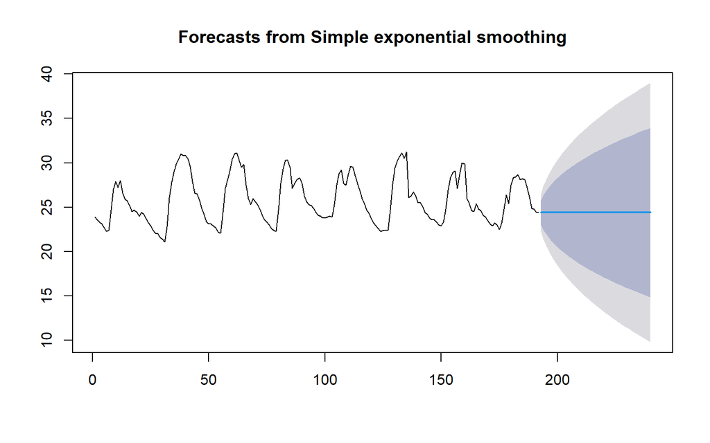

```r
#ses
ses.opt <- ses(train_ma.ts, h = length(test_ma.ts), alpha = NULL); plot(ses.opt)
```

```r
ses.opt$model
```

```
## Simple exponential smoothing
##
## Call:
## ses(y = train_ma.ts, h = length(test_ma.ts), alpha = NULL)
##
##   Smoothing parameters:
##     alpha = 0.9999
##
##   Initial states:
##     l = 23.9002
##
##   sigma:  1.0755
##
##      AIC     AICc      BIC
## 1041.375 1041.503 1051.147
```

```r
#Lamda Optimum Holt Winter
HWopt<- HoltWinters(train_ma.ts, gamma = FALSE, beta = FALSE,alpha = NULL)
HWopt
```

```
## Holt-Winters exponential smoothing without trend and without seasonal component.
##
## Call:
## HoltWinters(x = train_ma.ts, alpha = NULL, beta = FALSE, gamma = FALSE)
##
## Smoothing parameters:
##  alpha: 0.9999542
##  beta : FALSE
##  gamma: FALSE
##
## Coefficients:
##   [,1]
## a 24.4
```

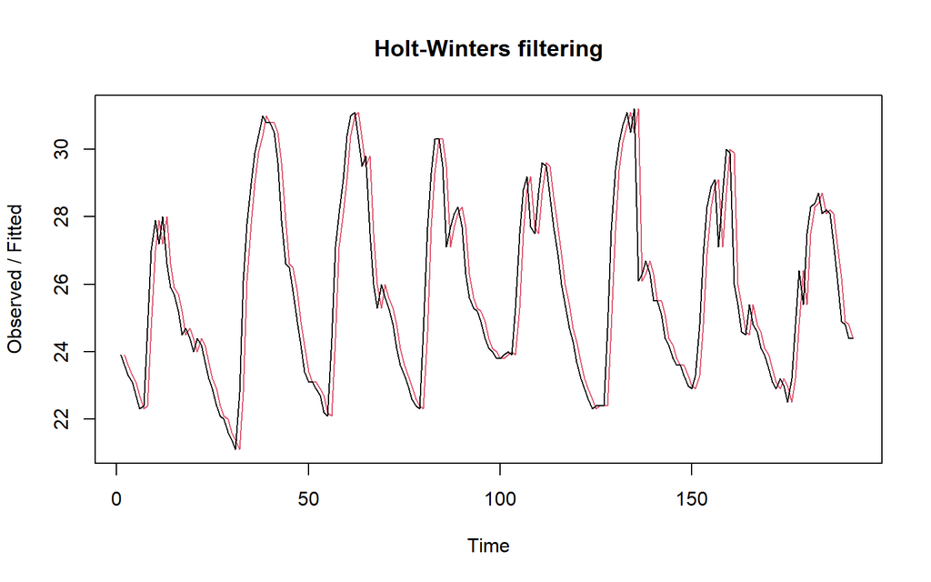

```r
plot(HWopt)
```

```r
#ramalan
ramalanopt<- forecast(HWopt, h=10); ramalanopt
```

```
##     Point Forecast    Lo 80    Hi 80    Lo 95    Hi 95
## 193           24.4 23.02174 25.77826 22.29213 26.50787
## 194           24.4 22.45089 26.34911 21.41909 27.38091
## 195           24.4 22.01286 26.78714 20.74918 28.05082
## 196           24.4 21.64358 27.15642 20.18441 28.61559
## 197           24.4 21.31823 27.48177 19.68684 29.11316
## 198           24.4 21.02410 27.77590 19.23700 29.56300
## 199           24.4 20.75361 28.04639 18.82333 29.97667
## 200           24.4 20.50185 28.29815 18.43829 30.36171
## 201           24.4 20.26539 28.53461 18.07666 30.72334
## 202           24.4 20.04174 28.75826 17.73462 31.06538
```

Setelah dilakukan peramalan, akan dilakukan perhitungan keakuratan hasil peramalan. Perhitungan akurasi ini dilakukan baik pada data latih dan data uji.

### 7.3.1 Akurasi Data Latih SES

```r
ses_n1.fitted <- ses.opt$fitted
error_train.ses.n1 <- train_ma.ts - ses_n1.fitted

SSE_train.ses.n1 <- sum(error_train.ses.n1^2)
MSE_train.ses.n1 <- mean(error_train.ses.n1^2)
MAPE_train.ses.n1 <- mean(abs(error_train.ses.n1/train_ma.ts)*100)

akurasi_train.ses.n1 <- matrix(c(SSE_train.ses.n1, MSE_train.ses.n1, MAPE_train.ses.n1))
row.names(akurasi_train.ses.n1) <- c("SSE", "MSE", "MAPE")
colnames(akurasi_train.ses.n1) <- c("Akurasi Data Latih SES")
akurasi_train.ses.n1
```

```
##      Akurasi Data Latih SES
## SSE              219.769139
## MSE                1.144631
## MAPE               2.817917
```

### 7.3.2 Akurasi Data Uji SES

Akurasi data uji dapat dihitung dengan cara yang hampir sama dengan perhitungan akurasi data latih.

```r
ses_n1.ramal <- as.numeric(ses.opt$mean)
error_test.ses.n1 <- test_ma.ts - ses_n1.ramal

SSE_test.ses.n1 <- sum(error_test.ses.n1^2)
MSE_test.ses.n1 <- mean(error_test.ses.n1^2)
MAPE_test.ses.n1 <- mean(abs(error_test.ses.n1/test_ma.ts)*100)

akurasi_test.ses.n1 <- matrix(c(SSE_test.ses.n1, MSE_test.ses.n1, MAPE_test.ses.n1))
row.names(akurasi_test.ses.n1) <- c("SSE", "MSE", "MAPE")
colnames(akurasi_test.ses.n1) <- c("Akurasi Data Uji SES")
akurasi_test.ses.n1
```

```
##      Akurasi Data Uji SES
## SSE            261.360000
## MSE              5.445000
## MAPE             6.076094
```

## 7.4 Double Exponential Smoothing (DES)

Digunakan alpha dan beta optimum (dipilih otomatis oleh `HoltWinters()` dengan `gamma = FALSE`).

```r
des_opt <- HoltWinters(train_ma.ts, gamma = FALSE)
des_opt
```

```
## Holt-Winters exponential smoothing with trend and without seasonal component.
##
## Call:
## HoltWinters(x = train_ma.ts, gamma = FALSE)
##
## Smoothing parameters:
##  alpha: 1
##  beta : 0.4695355
##  gamma: FALSE
##
## Coefficients:
##        [,1]
## a 24.400000
## b -0.259704
```

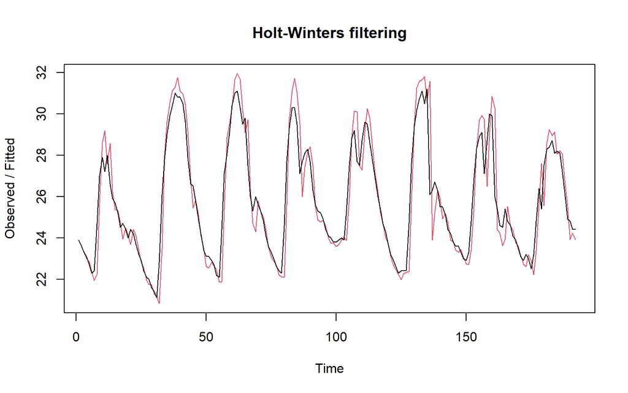

```r
plot(des_opt)
```

```r
#ramalan
ramalandesopt<- forecast(des_opt, h=length(test_ma.ts))
ramalandesopt
```

```
##     Point Forecast        Lo 80     Hi 80        Lo 95     Hi 95
## 193       24.14030   22.7761198  25.50447   22.0539685  26.22662
## 194       23.88059   21.4557579  26.30543   20.1721282  27.58906
## 195       23.62089   20.0324223  27.20935   18.1328033  29.10897
## 196       23.36118   18.4956595  28.22671   15.9200064  30.80236
## 197       23.10148   16.8493521  29.35361   13.5396754  32.66329
## 198       22.84178   15.0993626  30.58419   11.0007764  34.68278
## 199       22.58207   13.2513984  31.91275    8.3120380  36.85211
## 200       22.32237   11.3105937  33.33414    5.4813124  39.16342
## 201       22.06266    9.2814814  34.84385    2.5155319  41.60980
## 202       21.80296    7.1680568  36.43786   -0.5791932  44.18511
## 203       21.54326    4.9738560  38.11266   -3.7974549  46.88397
## 204       21.28355    2.7020272  39.86508   -7.1344381  49.70154
## 205       21.02385    0.3553918  41.69231  -10.5858283  52.63353
## 206       20.76414   -2.0635065  43.59180  -14.1477351  55.67602
```

[output cut: 34 more lines]

Selanjutnya akan dilakukan perhitungan akurasi pada data latih maupun data uji dengan ukuran akurasi SSE, MSE dan MAPE.

### 7.4.1 Akurasi Data Latih DES

```r
#Akurasi Data Training
des_n1.fitted <- des_opt$fitted
error_train.des.n1 <- train_ma.ts[-(1:2)] - des_n1.fitted

SSE_train.des.n1 <- sum(error_train.des.n1^2)
MSE_train.des.n1 <- mean(error_train.des.n1^2)
MAPE_train.des.n1 <- mean(abs(error_train.des.n1/train_ma.ts[-(1:2)])*100)

akurasi_train.des.n1 <- matrix(c(SSE_train.des.n1, MSE_train.des.n1, MAPE_train.des.n1))
row.names(akurasi_train.des.n1) <- c("SSE", "MSE", "MAPE")
colnames(akurasi_train.des.n1) <- c("Akurasi Data Latih DES")
akurasi_train.des.n1
```

```
##      Akurasi Data Latih DES
## SSE             128114.2857
## MSE                224.7619
## MAPE                35.2071
```

### 7.4.2 Akurasi Data Uji DES

Akurasi data uji dapat dihitung dengan cara yang hampir sama dengan perhitungan akurasi data latih.

```r
des_n1.ramal <- as.numeric(ramalandesopt$mean)
error_test.des.n1 <- test_ma.ts - des_n1.ramal

SSE_test.des.n1 <- sum(error_test.des.n1^2)
MSE_test.des.n1 <- mean(error_test.des.n1^2)
MAPE_test.des.n1 <- mean(abs(error_test.des.n1/test_ma.ts)*100)

akurasi_test.des.n1 <- matrix(c(SSE_test.des.n1, MSE_test.des.n1, MAPE_test.des.n1))
row.names(akurasi_test.des.n1) <- c("SSE", "MSE", "MAPE")
colnames(akurasi_test.des.n1) <- c("Akurasi Data Uji DES")
akurasi_test.des.n1
```

```
##      Akurasi Data Uji DES
## SSE            3641.81812
## MSE              75.87121
## MAPE             27.42889
```

Bagi Data Latih dan Data Uji hasil akurasi SES lebih baik dibandingkan dengan menggunakan DES.

## 7.5 Winter Aditif

Winter butuh data ts dengan frequency (periode musiman), jadi dibuat objek time series baru khusus (frequency = 24, karena data per jam):

```r
#membagi data menjadi training dan testing
training.ts<-ts(as.numeric(train_ma.ts), frequency = 24)
testing.ts<-ts(as.numeric(test_ma.ts), frequency = 24)
h <- length(testing.ts)
```

```r
w1 <- HoltWinters(training.ts, seasonal = "additive")
w1
```

```
## Holt-Winters exponential smoothing with trend and additive seasonal component.
##
## Call:
## HoltWinters(x = training.ts, seasonal = "additive")
##
## Smoothing parameters:
##  alpha: 0.9559874
##  beta : 0.001107512
##  gamma: 1
##
## Coefficients:
##            [,1]
## a   24.97708599
## b    0.06848180
## s1  -1.05127005
## s2  -1.63341737
## s3  -2.14393202
## s4  -2.51336296
## s5  -3.04825954
## s6  -3.53411979
## s7  -3.98991935
## s8  -2.47696095
## s9   0.50046727
## s10  2.23895424
## s11  3.25769972
## s12  4.18095066
## s13  2.90641542
## s14  2.09900619
## s15  1.86101441
## s16  1.10208861
## s17  0.54399266
## s18  0.56310672
## s19  0.28131323
## s20  0.04168937
## s21  0.48369163
## s22  0.40045353
## s23 -0.03672733
## s24 -0.57708599
```

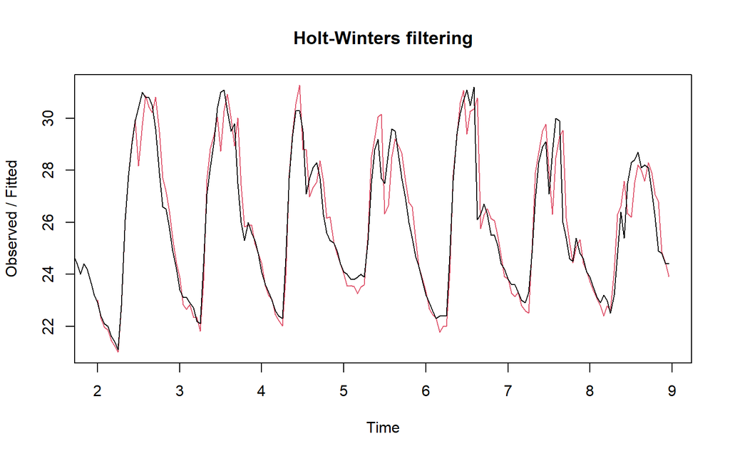

```r
plot(w1)
```

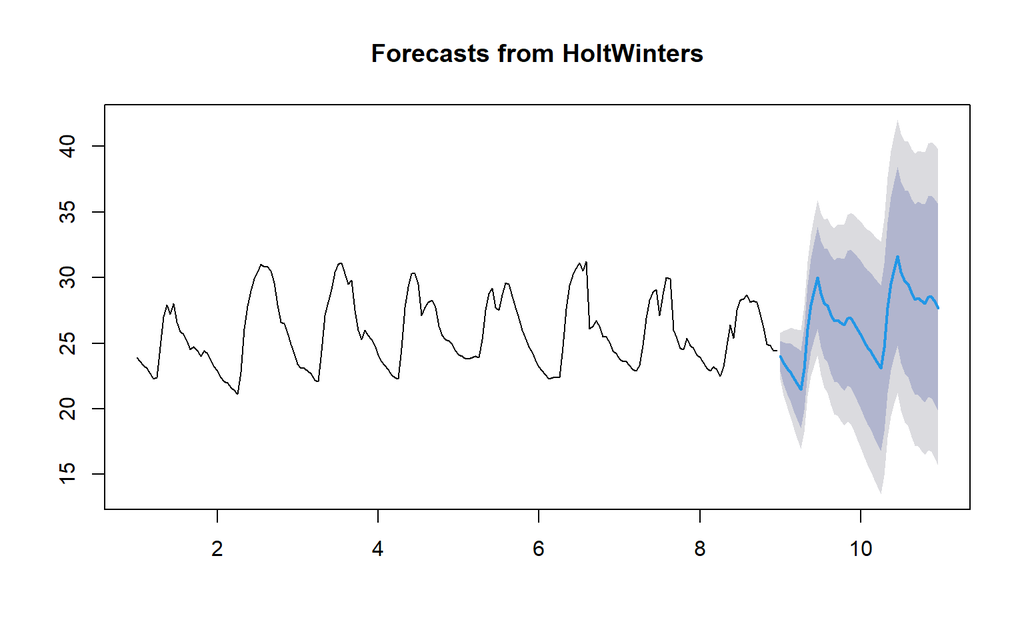

```r
ramalan.w1 <- forecast(w1, h = h)
plot(ramalan.w1)
```

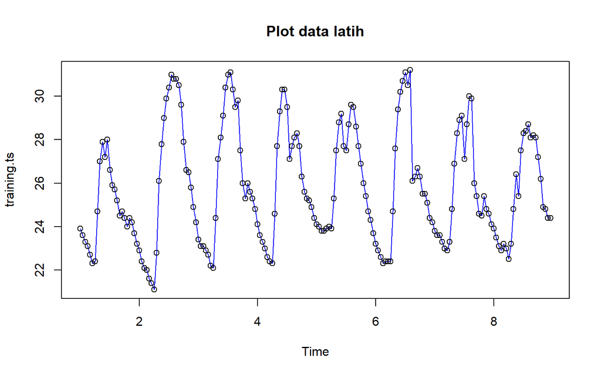

```r
plot(training.ts, col="blue",main="Plot data latih")
points(training.ts)
```

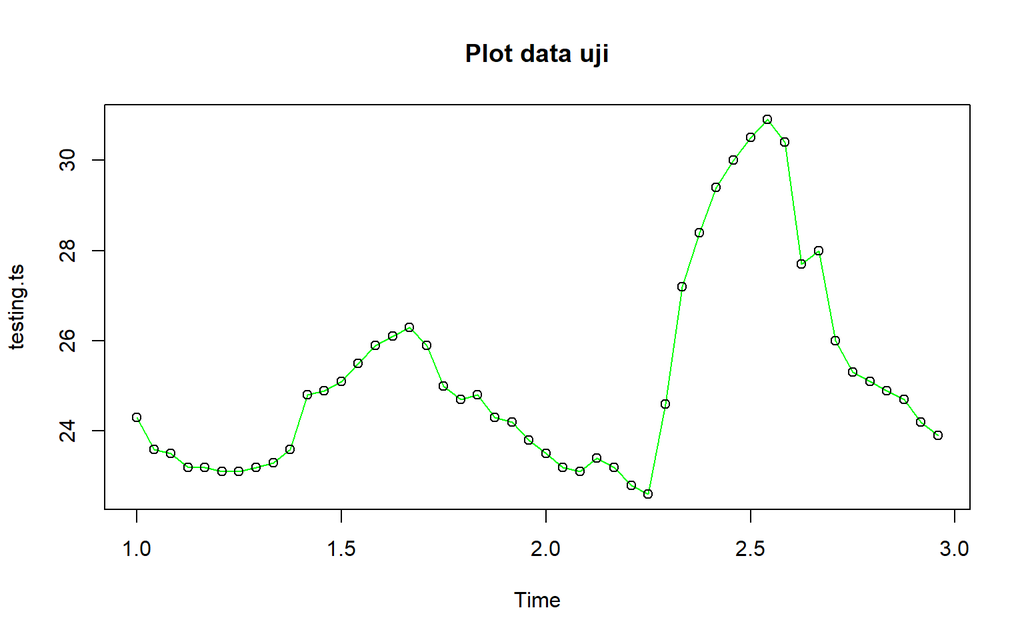

```r
plot(testing.ts, col="green",main="Plot data uji")
points(testing.ts)
```

### 7.5.1 Akurasi Data Latih - Winter Aditif

```r
fitted.w1 <- w1$fitted[,1]
akt_w1.n1 <- data1.ts[(length(data1.ts) - length(fitted.w1) + 1):length(data1.ts)]
error_train.w1 <- akt_w1.n1 - fitted.w1

SSE_train.w1 <- sum(error_train.w1^2)
MSE_train.w1 <- mean(error_train.w1^2)
MAPE_train.w1 <- mean(abs(error_train.w1/akt_w1.n1)) * 100

akurasi_train.w1 <- matrix(c(SSE_train.w1, MSE_train.w1, MAPE_train.w1))
row.names(akurasi_train.w1) <- c("SSE", "MSE", "MAPE")
colnames(akurasi_train.w1) <- "Akurasi Data Latih Winter Aditif"
akurasi_train.w1
```

```
##      Akurasi Data Latih Winter Aditif
## SSE                        504.741433
## MSE                          3.004413
## MAPE                         4.932289
```

### 7.5.2 Akurasi Data Uji - Winter Aditif

```r
forecast.w1 <- as.numeric(ramalan.w1$mean)
error_test.w1 <- as.numeric(testing.ts) - forecast.w1
SSE_test.w1 <- sum(error_test.w1^2)
MSE_test.w1 <- mean(error_test.w1^2)
MAPE_test.w1 <- mean(abs(error_test.w1/as.numeric(testing.ts))) * 100

akurasi_test.w1 <- matrix(c(SSE_test.w1, MSE_test.w1, MAPE_test.w1))
row.names(akurasi_test.w1) <- c("SSE", "MSE", "MAPE")
colnames(akurasi_test.w1) <- "Akurasi Data Uji Winter Aditif"
akurasi_test.w1
```

```
##      Akurasi Data Uji Winter Aditif
## SSE                      231.106608
## MSE                        4.814721
## MAPE                       7.137279
```

## 7.6 Winter Multiplikatif

```r
w2 <- HoltWinters(training.ts, seasonal = "multiplicative")
w2
```

```
## Holt-Winters exponential smoothing with trend and multiplicative seasonal component.
##
## Call:
## HoltWinters(x = training.ts, seasonal = "multiplicative")
##
## Smoothing parameters:
##  alpha: 0.9580964
##  beta : 0.002813521
##  gamma: 1
##
## Coefficients:
##            [,1]
## a   25.01261800
## b    0.05169754
## s1   0.95597299
## s2   0.93197209
## s3   0.91160414
## s4   0.89758079
## s5   0.87680093
## s6   0.85879760
## s7   0.84180252
## s8   0.90162244
## s9   1.01897388
## s10  1.08839068
## s11  1.12836433
## s12  1.16479331
## s13  1.11656057
## s14  1.08527495
## s15  1.07602134
## s16  1.04645382
## s17  1.02310955
## s18  1.02448564
## s19  1.01320835
## s20  1.00269158
## s21  1.02036330
## s22  1.01681686
## s23  0.99825414
## s24  0.97550764
```

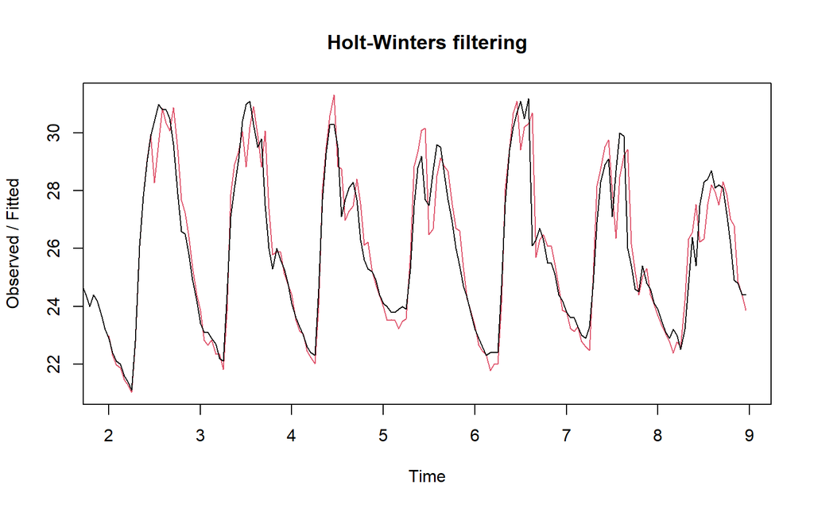

```r
plot(w2)
```

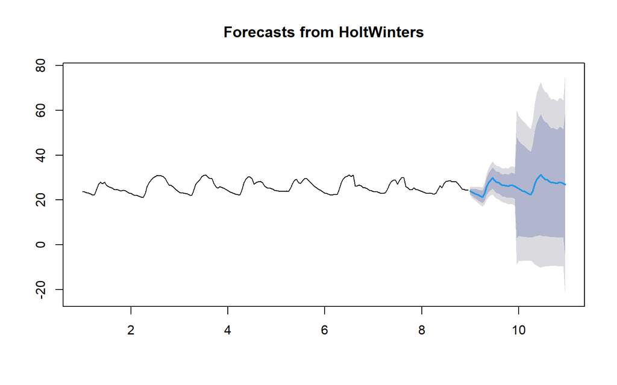

```r
ramalan.w2 <- forecast(w2, h = h)
plot(ramalan.w2)
```

### 7.6.1 Akurasi Data Latih - Winter Multiplikatif

```r
fitted.w2 <- w2$fitted[,1]
akt_w2.n1 <- data1.ts[(length(data1.ts) - length(fitted.w2) + 1):length(data1.ts)]
error_train.w2 <- akt_w2.n1 - fitted.w2

SSE_train.w2 <- sum(error_train.w2^2)
MSE_train.w2 <- mean(error_train.w2^2)
MAPE_train.w2 <- mean(abs(error_train.w2/akt_w2.n1)) * 100

akurasi_train.w2 <- matrix(c(SSE_train.w2, MSE_train.w2, MAPE_train.w2))
row.names(akurasi_train.w2) <- c("SSE", "MSE", "MAPE")
colnames(akurasi_train.w2) <- "Akurasi Data Latih Winter Multiplikatif"
akurasi_train.w2
```

```
##      Akurasi Data Latih Winter Multiplikatif
## SSE                               508.464139
## MSE                                 3.026572
## MAPE                                4.948069
```

### 7.6.2 Akurasi Data Uji - Winter Multiplikatif

```r
forecast.w2 <- as.numeric(ramalan.w2$mean)
error_test.w2 <- as.numeric(testing.ts) - forecast.w2
SSE_test.w2 <- sum(error_test.w2^2)
MSE_test.w2 <- mean(error_test.w2^2)
MAPE_test.w2 <- mean(abs(error_test.w2/as.numeric(testing.ts))) * 100

akurasi_test.w2 <- matrix(c(SSE_test.w2, MSE_test.w2, MAPE_test.w2))
row.names(akurasi_test.w2) <- c("SSE", "MSE", "MAPE")
colnames(akurasi_test.w2) <- "Akurasi Data Uji Winter Multiplikatif"
akurasi_test.w2
```

```
##      Akurasi Data Uji Winter Multiplikatif
## SSE                             180.950291
## MSE                               3.769798
## MAPE                              6.135692
```

Bagi Data Latih Winter Adaptif menghasilkan akurasi yang lebih baik dibandingkan Winter Multiplikatif. Sedangkan bagi Data Uji Winter Multiplikatif memiliki akurasi yang lebih baik dibandingkan Winter Adaptif.

# 8 Perbandingan Akurasi Antar Metode

```r
perbandingan <- data.frame(
  Metode = c("SMA (m=4)", "DMA (m=4)", "SES (alpha optimum)",
             "DES (alpha & beta optimum)",
             "Winter Aditif", "Winter Multiplikatif"),
  SSE_Latih = c(SSE_train.sma, SSE_train.dma, SSE_train.ses.n1, SSE_train.des.n1,
                SSE_train.w1, SSE_train.w2),
  MSE_Latih = c(MSE_train.sma, MSE_train.dma, MSE_train.ses.n1, MSE_train.des.n1,
                MSE_train.w1, MSE_train.w2),
  MAPE_Latih = c(MAPE_train.sma, MAPE_train.dma, MAPE_train.ses.n1, MAPE_train.des.n1,
                 MAPE_train.w1, MAPE_train.w2),
  SSE_Uji = c(SSE_test.sma, SSE_test.dma, SSE_test.ses.n1, SSE_test.des.n1,
              SSE_test.w1, SSE_test.w2),
  MSE_Uji = c(MSE_test.sma, MSE_test.dma, MSE_test.ses.n1, MSE_test.des.n1,
              MSE_test.w1, MSE_test.w2),
  MAPE_Uji = c(MAPE_test.sma, MAPE_test.dma, MAPE_test.ses.n1, MAPE_test.des.n1,
               MAPE_test.w1, MAPE_test.w2)
)

knitr::kable(perbandingan, digits = 4)
```

| Metode | SSE_Latih | MSE_Latih | MAPE_Latih | SSE_Uji | MSE_Uji | MAPE_Uji |
| --- | --- | --- | --- | --- | --- | --- |
| SMA (m=4) | 711.7631 | 3.7860 | 5.6765 | 247.0500 | 5.1469 | 6.0595 |
| DMA (m=4) | 550.8862 | 2.9778 | 4.7338 | 16640.8183 | 346.6837 | 62.2703 |
| SES (alpha optimum) | 219.7691 | 1.1446 | 2.8179 | 261.3600 | 5.4450 | 6.0761 |
| DES (alpha & beta optimum) | 128114.2857 | 224.7619 | 35.2071 | 3641.8181 | 75.8712 | 27.4289 |
| Winter Aditif | 504.7414 | 3.0044 | 4.9323 | 231.1066 | 4.8147 | 7.1373 |
| Winter Multiplikatif | 508.4641 | 3.0266 | 4.9481 | 180.9503 | 3.7698 | 6.1357 |

```r
# cari metode terbaik otomatis (MAPE data uji terkecil)
best_metode <- perbandingan$Metode[which.min(perbandingan$MAPE_Uji)]
best_metode
```

```
## [1] "SMA (m=4)"
```

Sehingga didapatkan metode terbaik adalah Single Moving Average (SMA) dengan m=4 dengan MAPE sebesar 6.06% pada nilai MAPE Data UJi yang terkecil. Nilai ini termasuk dalam kategori sangat baik karena kurang dari 10%, yang berarti metode ini memiliki tingkat akurasi yang tinggi dalam memprediksi suhu di luar periode latih. Sebaliknya didapatkan performa yang sangat buruk pada data uji (MAPE 62,27%) pada metode DMA yang mengindikasikan metode ini overfitting terhadap data latih dan tidak dapat menggeneralisasi pola data dengan baik sebab volatilitas data suhu yang cukup tinggi.